# In-Game NLL Prediction

Jack Davis

2024-03-12

# Why this project?

Why the national lacrosse league (growing rapidly in advertising budget, no easy public play by play data API yet, not much in terms of published analytics, Sportlogiq might be able to give me data, so I want to demonstrate what I can do first.

https://www.tsn.ca/lacrosse/proof-in-the-numbers-nll-ownership-groups-amongst-biggest-in-pro-sports-1.1910521

https://www.nll.com/news/lax101-the-growth-of-lacrosse/

Also, lacrosse is awesome to watch and tickets are still cheap.

ALSO, Ottawa is getting a team next year.

# Why this project?

Why a win percentage over time?

It’s…

- easy to consume and understand,
- easy to build upon under the hood,
- easy to evaluate,
- easy to adapt from soccer and hockey.

# Data Acquisition

Used the 2022-23 schedule page to get all the links to the 2022-23 games and 2023-24 games and just copied over the URLs manually. (This is bad future proofing practice but it was way less work) https://www.nll.com/schedule/full-schedule/

[figure not shown]

# Data Acquisition

Game recap: https://www.nll.com/game/803479313/panther-city-lacrosse-club-vs-vancouver-warriors/2023-12-01/

[figure not shown]

# Data Acquisition

Used code from web scraping 101 at https://rvest.tidyverse.org/articles/rvest.html

I might be able to leverage Sportlogiq’s data in the future anyways.

```r
if(scrape)
{
  html <- read_html(addresses[addcount])

  parts <- html %>%
    html_elements("li") %>%
    html_text2()

  Sys.sleep(10)
  ...
```

# Data Cleaning

Found the table I was looking for in raw text. (I know there are ways to do this that we discussed last time, but this way turned out to be really fast)

Did it for a single overtime game first and then moved on. Used a for loop because information on row depended on previous rows (e.g. first quarter, and what the previous score was to determine what team scored)

```r
 if(str_detect(this_str, "^[0-9]"))
  {
    Ngoals = Ngoals + 1

    score_str = str_extract(this_str, "[0-9]+$")
    away_scored_str = paste(away_score_sofar + 1, home_score_sofar, sep="")
    home_scored_str = paste(away_score_sofar, home_score_sofar + 1, sep="")

    if(score_str == away_scored_str)
    {
      away_score_sofar = away_score_sofar + 1
    }
    if(score_str == home_scored_str)
    {
      home_score_sofar = home_score_sofar + 1
    }

    away_score[Ngoals] = away_score_sofar
    home_score[Ngoals] = home_score_sofar

    min_left = as.numeric(unlist(str_extract_all(this_str, "[0-9]+"))[1])
    sec_left = as.numeric(unlist(str_extract_all(this_str, "[0-9]+"))[2])
    goal_time_left[Ngoals] = qrts_left*900 + min_left*60 + sec_left
```

# Data Cleaning

```r
> output_all[21:23,]
   away_str home_str away_score home_score goal_time_left isgoal goal_time gamecount  gamecode
21      SAS      HFX          0          0           3400      0       200         1 803475489
22      SAS      HFX          0          1           3398      1       202         1 803475489
23      SAS      HFX          0          1           3390      0       210         1 803475489
     gamedate away_goals_rate_const home_goals_rate_const away_goals_rate_modelled
21 2023-12-01              11.71111              11.51111                 12.71266
22 2023-12-01              11.71111              11.51111                 12.71266
23 2023-12-01              11.71111              11.51111                 12.71266
   home_goals_rate_modelled home_wins away_win_pr_const home_win_pr_const away_win_pr_modelled
21                 12.47987         1         0.5174922         0.4825078            0.5194832
22                 12.47987         1         0.4246121         0.5753879            0.4305716
23                 12.47987         1         0.4244750         0.5755250            0.4304374
   home_win_pr_modelled
21            0.4805168
22            0.5694284
23            0.5695626
```

# Team-Agnostic Model

The first model I used was a team agnostic model. It takes the regulation average goals per hour (goals per game but with overtime removed ), and uses that as the future goal rate for each team in a joint independent poisson model.

The model just makes a matrix of the joint probabilities of each future goals scored up to 30 per team. Then it adds up all the ones that lead to the home team winning, dividing out the ones that lead to a tie.

```r
ggplot(game1, aes(x=goal_time/60, y=home_win_pr_modelled)) +
  geom_line(lwd=2, aes(x=goal_time/60, y=home_win_pr_const)) +
 # geom_line(lwd=2, col="Red") +
  coord_cartesian(ylim = c(0,1) ) +
  theme_bw() +
  geom_hline(yintercept = c(0, 0.50, 1)) +
  #geom_vline(xintercept = c(0, 15, 30, 45, 60), col="Grey") +
  annotate("text", x=10, y=0.95, label= "Vancouver Warriors Win") +
  annotate("text", x=10, y=0.05, label= "Panther City Lacrosse Win") +
  labs(title = "Panther City Lacrosse (Bottom) @ Vancouver Warriors (Top)",
       subtitle = "2023-12-01 Game, Full Prediction") +
  xlab("Game Time (Minutes)") +
  ylab("Pr(Home Team Wins)")
```

# Team-Agnostic Model

```r
> head(dat_game_ends, n=4)
     away_str home_str away_score home_score goal_time_left isgoal goal_time gamecount  gamecode
390       SAS      HFX         12         17              0      0      3600         1 803475489
773       ALB       LV         12         10              0      0      3600         2 803476769
1152      PCL      VAN         11          7              0      0      3600         3 803479313
1540      CGY      ROC         13         14              0      0      3600         4 803476002
       gamedate away_goals_rate_const home_goals_rate_const away_goals_rate_modelled
390  2023-12-01              11.71111              11.51111                 12.71266
773  2023-12-01              11.71111              11.51111                 13.52533
1152 2023-12-01              11.71111              11.51111                 11.28659
1540 2023-12-02              11.71111              11.51111                 12.76043
     home_goals_rate_modelled home_wins away_win_pr_const home_win_pr_const away_win_pr_modelled
390                 12.479869         1                 0                 1                    0
773                 10.146226         0                 1                 0                    1
1152                 8.997528         0                 1                 0                    1
1540                12.866140         1                 0                 1                    0
     home_win_pr_modelled
390                     1
773                     0
1152                    0
1540                    1
```

```r
dat_game_ends$away_goals_rate_const = mean(dat_game_ends$away_score)
dat_game_ends$home_goals_rate_const = mean(dat_game_ends$home_score)
```

# Team-Agnostic Model

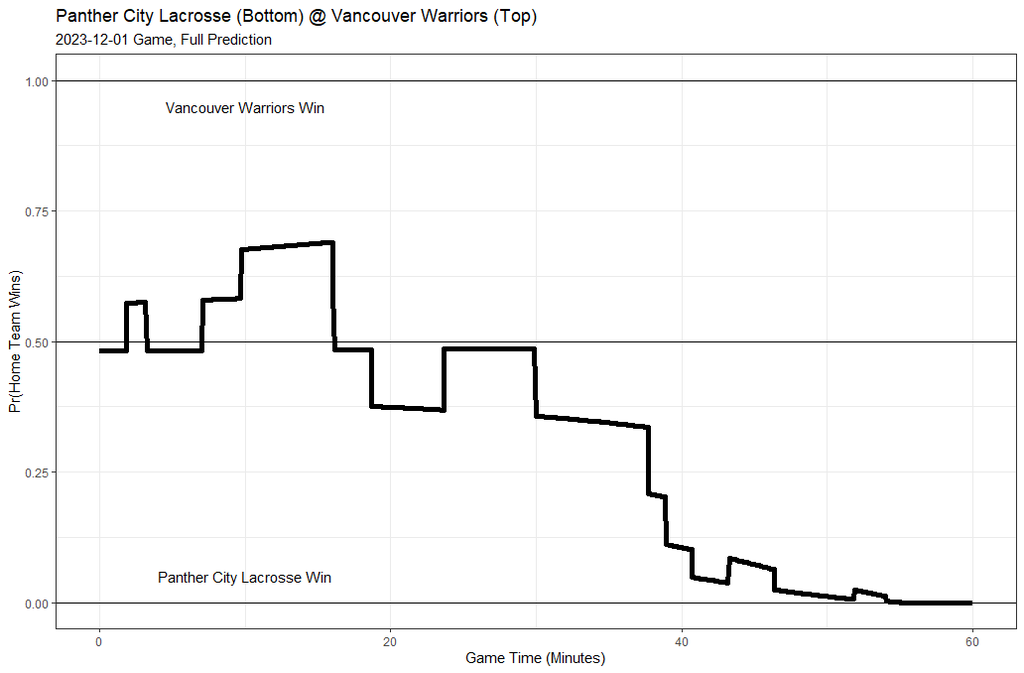

# Incorporating Team Strength

The next model I tried also used Poisson, but instead of treating teams as identical, it estimates how each home team will perform against each away team by estimating individual team effects and a home team effect. It does this with a poisson glm which is a standard practice from the 80s.

```r
mod_glm_home = glm(home_score ~ home_str + away_str,
                   family=poisson, data=dat_game_ends)

mod_glm_away = glm(away_score ~ home_str + away_str,
                   family=poisson, data=dat_game_ends)
```

$$\log(\mu) = \alpha +
\sum_i\beta_{home,i} + \sum_j\gamma_{away,j} + \epsilon$$

# Incorporating Team Strength

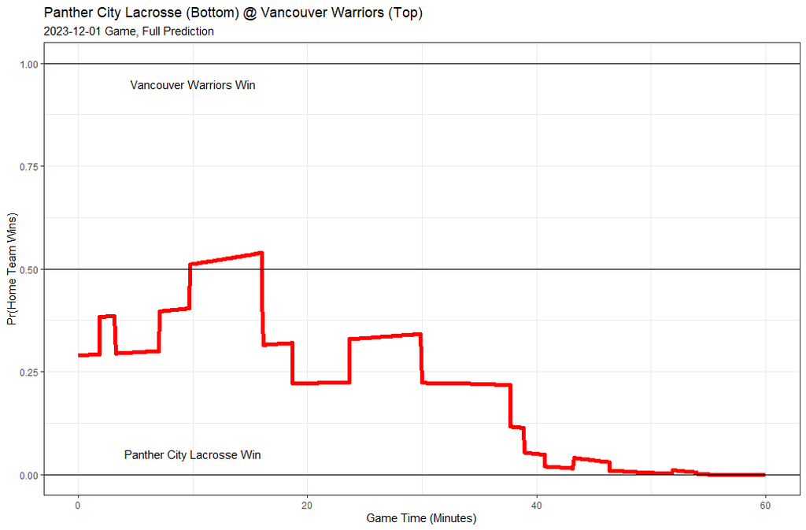

# Calibration

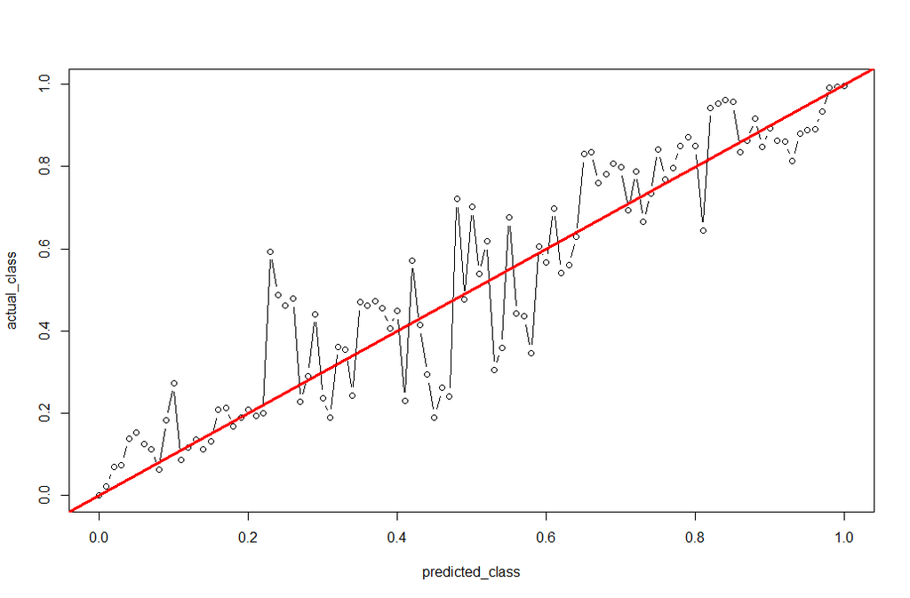

```r
predicted = round(output_all$home_win_pr_modelled, digits=2)
actual = output_all$home_wins

by_ob = by(actual, predicted, mean)

predicted_class = as.numeric(names(by_ob))
actual_class = as.numeric(by_ob)

plot(predicted_class, actual_class, type="b")
abline(0,1, lwd=3, col="red")
```

# Future Work

There’s lots more I could put into a model like this if I had the time and inclination.

- penalty power play effects
- injuries to the team roster
- ahead/behind dynamics (e.g. in the NHL the team that’s behind takes more shots, but worse shots)
- over dispersion (i.e. bursts of goals) in the form of zero inflated poisson, or negative binomial.
- different scoring rates in different quarters